# Project 3 - Main Script for Random Forest

Qingyang Zhong

# Step 0: Preparation

Install Required packages.

```r
if(!require("EBImage")){
  source("https://bioconductor.org/biocLite.R")
  biocLite("EBImage")
}
if(!require("randomForest")){
  install.packages("randomForest")
}
library("EBImage")
library("randomForest")
```

Specify directories.

Set the working directory to the image folder. In order to obain reproducible results, set.seed() whenever randomization is used.

```r
# here replace it with your own path or manually set it in RStudio to where this rmd file is located.
# use relative path for reproducibility
set.seed(8)
path<-setwd("~/Documents/GitHub/Fall2018-Proj3-Sec2--sec2proj3_grp10")
```

Provide directories for training images.

Low-resolution (LR) image set and High-resolution (HR) image set will be in different subfolders.

```r
train_dir <- "../data/train_set/"
train_LR_dir <- paste(train_dir, "LR/", sep="")
train_HR_dir <- paste(train_dir, "HR/", sep="")
train_label_path <- paste(train_dir, "label.csv", sep="")
```

### Step 1: set up controls for evaluation experiments.

In this chunk, we have a set of controls for the evaluation experiments.

- (T/F) cross-validation on the training set
- (number) K, the number of CV folds
- (T/F) process features for training set
- (T/F) run evaluation on an independent test set
- (T/F) process features for test set

```r
run.cv=TRUE # run cross-validation on the training set
K <- 10  # number of CV folds
run.feature.train=TRUE # process features for training set
run.test=TRUE # run evaluation on an independent test set
run.feature.test=TRUE # process features for test set
```

Potential parameter to be tuned.

Using cross-validation or independent test set evaluation, we compare the performance of models with different specifications. In this example, we use RandomForest with different `mtry` and `ntrees`.

In the following chunk, we list, in a vector, setups (in this case, `mtry`,`ntrees`) corresponding to models that we will compare.

```r
model_values1 <- seq(3, 7, 2)
model_values2 <- seq(300,700,200)

model_labels1 = paste("Randomforest with mtry =", model_values1)
model_labels2 = paste("Randomforest with ntrees =", model_values2)
```

### Step 2: import training images class labels.

```r
extra_label <- read.csv(train_label_path, colClasses=c("NULL", NA, NA))
```

### Step 3: construct features and responses

`feature_randomforest.R` should be the wrapper for all your feature engineering functions and options. The function `feature( )` should have options that correspond to different scenarios for your project and produces an R object that contains features and responses that are required by all the models you are going to evaluate later. + `feature_randomforest.R` + Input: a path for low-resolution images. + Input: a path for high-resolution images. + Output: an RData file that contains extracted features and corresponding responses

```r
source("../lib/feature_randomforest.R")
tm_feature_train <- NA
if(run.feature.train){
  tm_feature_train <- system.time(dat_train <- feature_randomforest(train_LR_dir, train_HR_dir))
  feat_train <- dat_train$feature
  label_train <- dat_train$label
}
save(dat_train, file="../output/feature_train.RData")
```

### Step 4: Train a classification model with training images

Call the train model and test model from library.

`train_randomforest.R` and `test_randomforest.R` should be wrappers for all your model training steps and your classification/prediction steps.

- `train_randomforest.R`
- Input: a path that points to the training set features and responses.
- Output: an RData file that contains trained classifiers in the forms of R objects: models/settings/links to external trained configurations.
- `test_randomforest.R`
- Input: a path that points to the test set features.
- Input: an R object that contains a trained classifier.
- Output: an R object of response predictions on the test set. If there are multiple classifiers under evaluation, there should be multiple sets of label predictions.

```r
source("../lib/train_randomforest.R")
source("../lib/test_randomforest.R")
```

#### Model selection with cross-validation

Do model selection by choosing among different values of training model parameters.

```r
source("../lib/cross_validation_randomforest.R")
if(run.cv){
  err_cv <- array(dim=c(length(model_values1)*length(model_values2), 2))
  for(k1 in 1:length(model_values1)){
    for(k2 in 1:length(model_values2)){
    cat("k1=", k1, ",k2=", k2, "\n")
    index <- (k1-1)*length(model_values2) + k2
    err_cv[index,] <- cv.function(feat_train, label_train, model_values1[k1], model_values2[k2], K)
    }
  }
  save(err_cv, file="../output/xgb_err_cv.RData")
}
```

```
k1= 1 ,k2= 1
k1= 1 ,k2= 2
k1= 1 ,k2= 3
k1= 2 ,k2= 1
k1= 2 ,k2= 2
k1= 2 ,k2= 3
k1= 3 ,k2= 1
k1= 3 ,k2= 2
k1= 3 ,k2= 3
```

Visualize cross-validation results.

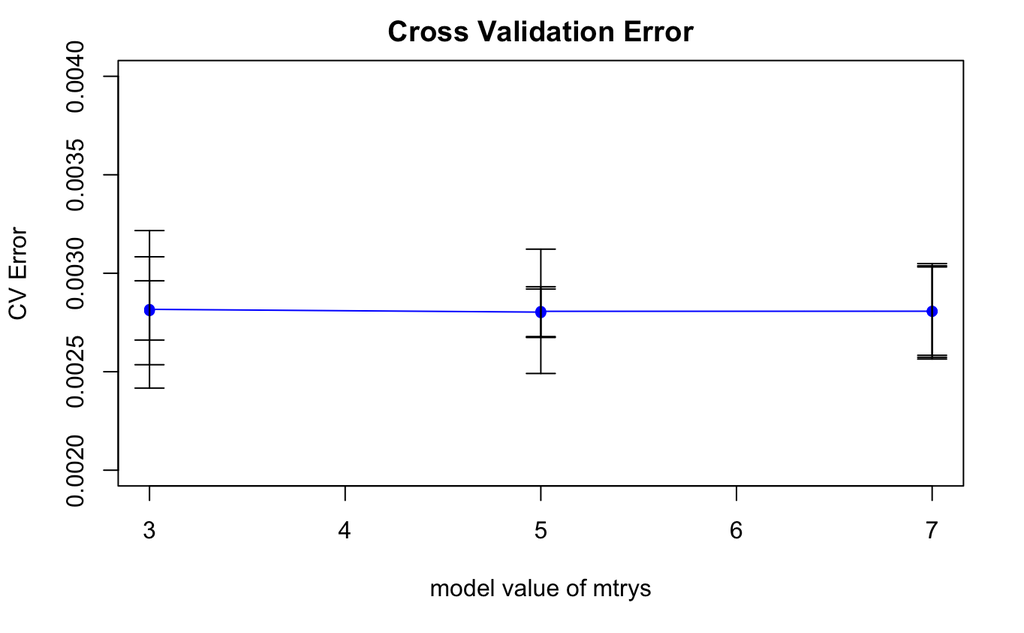

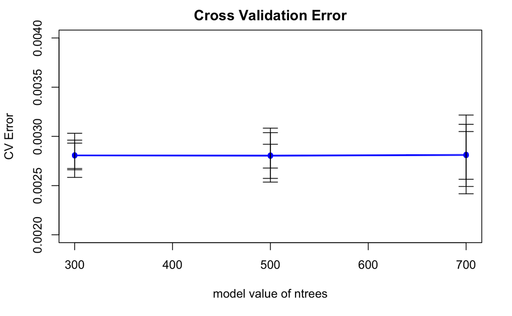

```r
if(run.cv){
 load("../output/err_cv.RData")
 err_cv  <- data.frame(err_cv)
 colnames(err_cv) <- c("cv_mean","cv_sd")
 par_mix <- expand.grid(model_values1, model_values2)
 colnames(par_mix) <- c("K1","K2")
 par_mix <- par_mix[order(par_mix$K1),]
 err_cv  <- cbind(err_cv, par_mix)

 plot(err_cv[,"K1"], err_cv[,1], xlab="model value of mtrys", ylab="CV Error",
       main="Cross Validation Error", type="n", ylim=c(0.002, 0.004))
 points(err_cv[,"K1"], err_cv[,1], col="blue", pch=16)
 lines(err_cv[,"K1"], err_cv[,1], col="blue")
 arrows(err_cv[,"K1"], err_cv[,1]-err_cv[,2], err_cv[,"K1"], err_cv[,1]+err_cv[,2],
        length=0.1, angle=90, code=3)

 plot(err_cv[,"K2"], err_cv[,1], xlab="model value of ntrees", ylab="CV Error",
       main="Cross Validation Error", type="n", ylim=c(0.002, 0.004))
 points(err_cv[,"K2"], err_cv[,1], col="blue", pch=16)
 lines(err_cv[,"K2"], err_cv[,1], col="blue")
 arrows(err_cv[,"K2"], err_cv[,1]-err_cv[,2], err_cv[,"K2"], err_cv[,1]+err_cv[,2],
        length=0.1, angle=90, code=3)
}
```

Choose the “best”" parameter value

```r
par_best
```

```
$mtry
[1] 5

$ntrees
[1] 500
```

Train the model with the entire training set using the selected model (model parameter) via cross-validation.

```r
tm_train=NA
tm_train <- system.time(fit_train <- train_randomforest(feat_train, label_train, par_best))
save(fit_train, file="../output/fit_train.RData")
```

### Step 5: Super-resolution for test images

Feed the final training model with the completely holdout testing data. + `superResolution_randomforest.R` + Input: a path that points to the folder of low-resolution test images. + Input: a path that points to the folder (empty) of high-resolution test images. + Input: an R object that contains tuned predictors. + Output: construct high-resolution versions for each low-resolution test image.

```r
source("../lib/superResolution_randomforest.R")
test_dir <- "../data/test_set/" # This will be modified for different data sets.
test_LR_dir <- paste(test_dir, "LR/", sep="")
test_HR_dir <- paste(test_dir, "HR/", sep="")
tm_test=NA
if(run.test){
  load(file="../output/fit_train_randomforest.RData")
  tm_test <- system.time(superResolution_randomforest(test_LR_dir, test_HR_dir, fit_train))
}
```